# Final_Project

Using Machine Learning to Classify  
the Outcome of Tennis Matches  
Based on Data Taken From Serves

```python
import pandas as pd
import numpy as np
from sklearn.metrics import accuracy_score
from sklearn.model_selection import train_test_split
from sklearn.naive_bayes import GaussianNB
from sklearn.tree import DecisionTreeClassifier
from random import randint
```

We will import data from 3 Grand Slams and merge them into 1 data frame.

```python
data1 = pd.read_csv('Wimbledon-women-2013.csv')
data2 = pd.read_csv('AusOpen-women-2013.csv')
data3 = pd.read_csv('USOpen-women-2013.csv')
frames = [data1,data2,data3]
data = pd.concat(frames)
```

Let get an idea for what our data looks like.

```python
data.shape
```

```
(325, 49)
```

That's a good amount of data. Lets see how many players we are looking at.

```python
print ('There are',len(set(data["Player1"].tolist() + data["Player2"].tolist()
        + data['Player 1'].tolist() + data['Player 2'].tolist())), 'unique players')
```

```
There are 336 unique players
```

```python
data.columns
```

```
Index(['ACE.1', 'ACE.2', 'BPC.1', 'BPC.2', 'BPW.1', 'BPW.2', 'DBF.1', 'DBF.2',
       'FNL.1', 'FNL.2', 'FNL1', 'FNL2', 'FSP.1', 'FSP.2', 'FSW.1', 'FSW.2',
       'NPA.1', 'NPA.2', 'NPW.1', 'NPW.2', 'Player 1', 'Player 2', 'Player1',
       'Player2', 'ROUND', 'Result', 'Round', 'SSP.1', 'SSP.2', 'SSW.1',
       'SSW.2', 'ST1.1', 'ST1.1.1', 'ST1.2', 'ST2.1', 'ST2.1.1', 'ST2.2',
       'ST3.1', 'ST3.2', 'ST4.1', 'ST4.2', 'ST5.1', 'ST5.2', 'TPW.1', 'TPW.2',
       'UFE.1', 'UFE.2', 'WNR.1', 'WNR.2'],
      dtype='object')
```

Since we only want to look at serve data, we will select the columns that pertain to serves  
That being: First and second serve percentage, the number of aces, and the number of double faults for both Player1 and Player2

```python
features = ['FSP.1','FSP.2','SSP.1','SSP.2','ACE.1','ACE.2','DBF.1','DBF.2']
```

Now let's clean up our data by filling in any NaN values with the mean of the column  
I do this instead of dropping rows with NaN values to perserve as much data as possible

```python
data_clean = data[features].fillna(data.mean())
data_clean.head()
```

|  | FSP.1 | FSP.2 | SSP.1 | SSP.2 | ACE.1 | ACE.2 | DBF.1 | DBF.2 |
| --- | --- | --- | --- | --- | --- | --- | --- | --- |
| 0 | 60 | 72 | 40 | 28 | 2.0 | 3.0 | 4.0 | 9.0 |
| 1 | 69 | 53 | 31 | 47 | 0.0 | 4.0 | 0.0 | 4.0 |
| 2 | 63 | 56 | 37 | 44 | 1.0 | 2.0 | 1.0 | 10.0 |
| 3 | 57 | 68 | 43 | 32 | 4.0 | 0.0 | 4.0 | 4.0 |
| 4 | 73 | 66 | 27 | 34 | 2.0 | 6.0 | 2.0 | 0.0 |

We also need to create and clean a dataframe for the match outcome

```python
# filling NaNs with a random 0 or 1 because
# filling with mean would not preserve the integer type for this column
data_outcome = data['Result'].fillna(randint(0,1))
data_outcome.head()
```

```
0    0
1    0
2    1
3    1
4    0
Name: Result, dtype: int64
```

We'll set our X to be the serve data and y to be the target

```python
X = data_clean.copy()
y = data_outcome.copy()
```

Now we perform the traing and test using Decision Tree Classifier

```python
X_train, X_test, y_train, y_test = train_test_split(X, y, test_size=0.33, random_state=324)
```

```python
result_classifier = DecisionTreeClassifier(max_leaf_nodes=10, random_state=0)
result_classifier.fit(X_train, y_train)
```

```
DecisionTreeClassifier(class_weight=None, criterion='gini', max_depth=None,
            max_features=None, max_leaf_nodes=10,
            min_impurity_decrease=0.0, min_impurity_split=None,
            min_samples_leaf=1, min_samples_split=2,
            min_weight_fraction_leaf=0.0, presort=False, random_state=0,
            splitter='best')
```

Here is the prediction on the test set

```python
predictions = result_classifier.predict(X_test)
```

```python
predictions[:10]
```

```
array([0, 1, 0, 0, 0, 0, 0, 1, 0, 1])
```

```python
y_test[:10]
```

```
69     0
4      1
39     1
52     0
111    0
96     1
35     0
70     1
97     0
27     1
Name: Result, dtype: int64
```

```python
accuracy_DT_women = accuracy_score(y_true = y_test, y_pred = predictions)
accuracy_DT_women
```

```
0.6388888888888888
```

Accuracy score of 0.63 is not bad. What if we used Naive Bayes instead?

```python
result_classifier = GaussianNB()
result_classifier.fit(X_train, y_train)
predictions = result_classifier.predict(X_test)
accuracy_NB_women = accuracy_score(y_true = y_test, y_pred = predictions)
accuracy_NB_women
```

```
0.7037037037037037
```

0.70 is a pretty good prediction! Now I want to know if this method of prediction will be the same for men.  
Since matches are generally shorter in men's games, I think the serve would have more weight in determining the outcome of the match, and therefore will be a better metric.

```python
data4 = pd.read_csv('Wimbledon-men-2013.csv')
data5 = pd.read_csv('AusOpen-men-2013.csv')
data6 = pd.read_csv('USOpen-men-2013.csv')
frames = [data4,data5,data6]
data_men = pd.concat(frames)

# features stays the same as before
data_clean_men = data_men[features].fillna(data_men.mean())

data_outcome_men = data_men['Result'].fillna(randint(0,1))

X = data_clean_men.copy()
y = data_outcome_men.copy()

X_train, X_test, y_train, y_test = train_test_split(X, y, test_size=0.33, random_state=324)

result_classifier = DecisionTreeClassifier(max_leaf_nodes=10, random_state=0)
result_classifier.fit(X_train, y_train)
predictions = result_classifier.predict(X_test)
accuracy_DT_men = accuracy_score(y_true = y_test, y_pred = predictions)

result_classifier = GaussianNB()
result_classifier.fit(X_train, y_train)
predictions = result_classifier.predict(X_test)
accuracy_NB_men = accuracy_score(y_true = y_test, y_pred = predictions)

print('Accuracy score for mens with Decision Tree Classifier is', accuracy_DT_men)
print('Accuracy score for mens with Naive Bayes is', accuracy_NB_men)
```

```
Accuracy score for mens with Decision Tree Classifier is 0.6528925619834711
Accuracy score for mens with Naive Bayes is 0.6611570247933884
```

That is a little lower than I expected but still pretty good. Maybe my interpretation of men's tennis is incorrect.

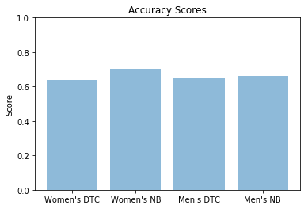

```python
import matplotlib.pyplot as plt

objects = ('Women\'s DTC','Women\'s NB','Men\'s DTC','Men\'s NB')
y_pos = np.arange(len(objects))
performance = [accuracy_DT_women,accuracy_NB_women,accuracy_DT_men,accuracy_NB_men]

plt.bar(y_pos, performance, align='center', alpha=0.5)
plt.xticks(y_pos, objects)
plt.ylabel('Score')
plt.title('Accuracy Scores')

axes = plt.gca()
axes.set_ylim([0,1])

plt.show()
```

Although the accuracy scores were not as high as I thought they would be, it still shows how much serves matter in the game. If you're someone who is looking for a way to win more games, this could indicate that practicing serve techniques can give you an extra edge on the courts.